# Exploratory Data analysis

```python
import os
import pandas as pd
import numpy as np
import matplotlib.pyplot as py
```

Inference: The code imports the necessary Python packages for data analysis and visualization, giving them alias names for ease of use in the code.

```python
team_stats=pd.read_csv("D:/end to end/team_stats.csv")
team_stats.head()
```

|  | Team 1 | Team 2 | Winner | Margin | Ground | Match Date | Scorecard |
| --- | --- | --- | --- | --- | --- | --- | --- |
| 0 | Namibia | Sri Lanka | Namibia | 55 runs | Geelong | Oct 16, 2022 | T20I # 1823 |
| 1 | Netherlands | U.A.E. | Netherlands | 3 wickets | Geelong | Oct 16, 2022 | T20I # 1825 |
| 2 | Scotland | West Indies | Scotland | 42 runs | Hobart | Oct 17, 2022 | T20I # 1826 |
| 3 | Ireland | Zimbabwe | Zimbabwe | 31 runs | Hobart | Oct 17, 2022 | T20I # 1828 |
| 4 | Namibia | Netherlands | Netherlands | 5 wickets | Geelong | Oct 18, 2022 | T20I # 1830 |

Inference: The code reads the 'team_stats.csv' file from the 'D:/end to end/' directory using the pd.read_csv function and stores the data in the team_stats DataFrame. The .head() method is then used to display the first few rows of the DataFrame.

```python
batsman_stats=pd.read_csv("D:/end to end/batsman_stats.csv")
batsman_stats.head()
```

|  | Player | Span | Mat | Inns | NO | Runs | HS | Ave | BF | SR | 100 | 50 | 0 | 4s | 6s |
| --- | --- | --- | --- | --- | --- | --- | --- | --- | --- | --- | --- | --- | --- | --- | --- |
| 0 | V Kohli (IND) | 2022-2022 | 6 | 6 | 3 | 296 | 82* | 98.66 | 217 | 136.40 | - | 4 | - | 25 | 8 |
| 1 | MP O'Dowd (NED) | 2022-2022 | 8 | 8 | 1 | 242 | 71* | 34.57 | 215 | 112.55 | - | 2 | - | 22 | 8 |
| 2 | SA Yadav (IND) | 2022-2022 | 6 | 6 | 2 | 239 | 68 | 59.75 | 126 | 189.68 | - | 3 | - | 26 | 9 |
| 3 | JC Buttler (ENG) | 2022-2022 | 6 | 6 | 1 | 225 | 80* | 45.00 | 156 | 144.23 | - | 2 | 1 | 24 | 7 |
| 4 | BKG Mendis (SL) | 2022-2022 | 8 | 8 | 1 | 223 | 79 | 31.85 | 156 | 142.94 | - | 2 | - | 17 | 10 |

Inference: The code reads the 'batsman_stats.csv' file from the 'D:/end to end/' directory using the pd.read_csv function and stores the data in the batsman_stats DataFrame. The .head() method is then used to display the first few rows of the DataFrame.

```python
bowlers_stats=pd.read_csv("D:/end to end/bowlers_stats.csv")
bowlers_stats.head()
```

|  | Player | Span | Mat | Inns | Balls | Overs | Mdns | Runs | Wkts | BBI | Ave | Econ | SR | 4 | 5 |
| --- | --- | --- | --- | --- | --- | --- | --- | --- | --- | --- | --- | --- | --- | --- | --- |
| 0 | PWH de Silva (SL) | 2022-2022 | 8 | 8 | 186 | 31.0 | 1 | 199 | 15 | 3/8 | 13.26 | 6.41 | 12.40 | - | - |
| 1 | SM Curran (ENG) | 2022-2022 | 6 | 6 | 136 | 22.4 | - | 148 | 13 | 5/10 | 11.38 | 6.52 | 10.46 | - | 1 |
| 2 | BFW de Leede (NED) | 2022-2022 | 8 | 7 | 132 | 22.0 | - | 169 | 13 | 3/19 | 13.00 | 7.68 | 10.15 | - | - |
| 3 | B Muzarabani (ZIM) | 2022-2022 | 8 | 7 | 156 | 26.0 | - | 199 | 12 | 3/23 | 16.58 | 7.65 | 13.00 | - | - |
| 4 | A Nortje (SA) | 2022-2022 | 5 | 5 | 105 | 17.3 | - | 94 | 11 | 4/10 | 8.54 | 5.37 | 9.54 | 2 | - |

Inference: The code reads the 'bowlers_stats.csv' file from the 'D:/end to end/' directory using the pd.read_csv function and stores the data in the bowlers_stats DataFrame. The .head() method is then used to display the first few rows of the DataFrame.

```python
bowling_stats=pd.read_csv("D:/end to end/bowling_stats.csv")
bowling_stats.head()
```

|  | Player | Overs | Mdns | Runs | Wkts | Econ | Team | Opposition | Ground | Match Date | Scorecard |
| --- | --- | --- | --- | --- | --- | --- | --- | --- | --- | --- | --- |
| 0 | SM Curran | 3.4 | - | 10 | 5 | 2.72 | England | v Afghanistan | Perth | 22 Oct 2022 | T20I # 1840 |
| 1 | A Nortje | 3.3 | - | 10 | 4 | 2.85 | South Africa | v Bangladesh | Sydney | 27 Oct 2022 | T20I # 1847 |
| 2 | TA Boult | 4.0 | - | 13 | 4 | 3.25 | New Zealand | v Sri Lanka | Sydney | 29 Oct 2022 | T20I # 1850 |
| 3 | AS Joseph | 4.0 | - | 16 | 4 | 4.00 | West Indies | v Zimbabwe | Hobart | 19 Oct 2022 | T20I # 1834 |
| 4 | Shaheen Shah Afridi | 4.0 | - | 22 | 4 | 5.50 | Pakistan | v Bangladesh | Adelaide | 06 Nov 2022 | T20I # 1872 |

Inference: The code reads the 'bowling_stats.csv' file from the 'D:/end to end/' directory using the pd.read_csv function and stores the data in the bowling_stats DataFrame. The .head() method is then used to display the first few rows of the DataFrame.

```python
battings_stats=pd.read_csv("D:/end to end/battings_stats.csv")
battings_stats.head()
```

[output not shown]

Inference: The code reads the 'battings_stats.csv' file from the 'D:/end to end/' directory using the pd.read_csv function and stores the data in the battings_stats DataFrame. The .head() method is then used to display the first few rows of the DataFrame.

# The Dataframe is read, let's consider some potential inferences:

Team Stats:

Investigating the distribution of victories among various teams. Identifying teams with the most and least win counts.

Batsman Stats:

Recognizing the top run-scorers in the tournament. Examining batting averages and strike rates. Identifying players with the highest number of centuries and half-centuries. Visualizing the distribution of boundaries (4s and 6s) for leading batsmen.

Bowlers Stats:

Identifying the leading wicket-takers in the tournament. Exploring bowling averages and economy rates. Checking for bowlers with the most 4-wicket and 5-wicket hauls.

Best Batting Performances:

Identifying players with the highest individual scores. Analyzing the strike rates and boundary counts for these outstanding innings. Examining the opposition teams and match venues associated with top batting performances.

Best Bowling Performances:

Identifying bowlers with the best figures in an innings. Exploring the economy rates for these exceptional bowling performances. Analyzing the opposition teams and match venues associated with top bowling performances.

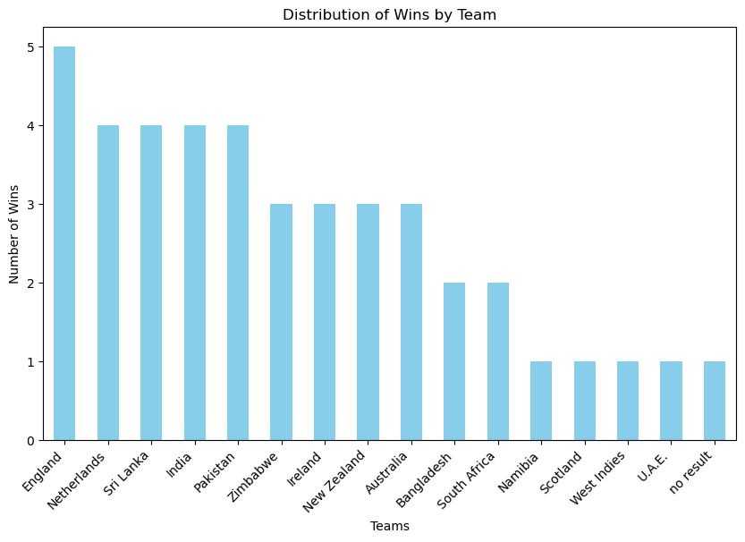

```python
import pandas as pd
import matplotlib.pyplot as plt

# Assuming team_stats is already loaded

# Count the number of wins for each team
team_wins = team_stats['Winner'].value_counts()

# Plotting the distribution of wins
plt.figure(figsize=(10, 6))
team_wins.plot(kind='bar', color='skyblue')
plt.title('Distribution of Wins by Team')
plt.xlabel('Teams')
plt.ylabel('Number of Wins')
plt.xticks(rotation=45, ha='right')
plt.show()
```

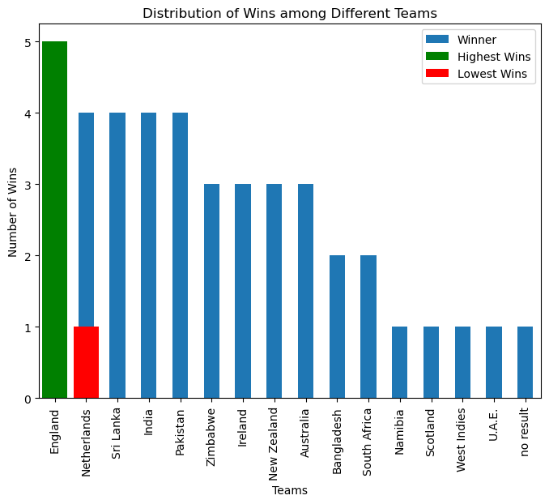

```python
plt.figure(figsize=(8, 6))
team_wins_distribution.plot(kind='bar', xlabel='Teams', ylabel='Number of Wins', title='Distribution of Wins among Different Teams')
plt.bar(teams_highest_wins, team_wins_distribution[teams_highest_wins], color='green', label='Highest Wins')
plt.bar(teams_lowest_wins, team_wins_distribution[teams_lowest_wins], color='red', label='Lowest Wins')
plt.legend()
plt.show()
```

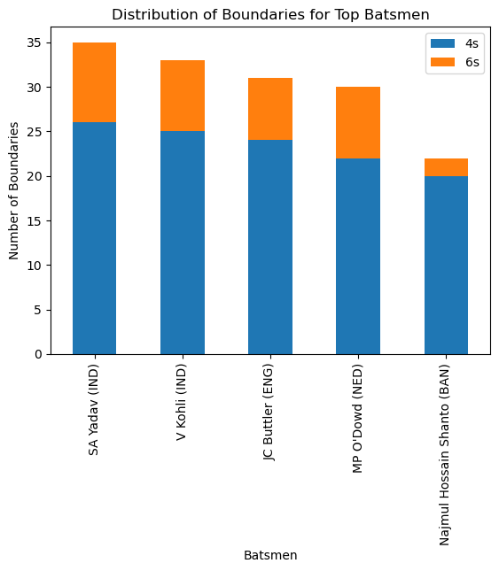

```python
# Top run-scorers
top_run_scorers = batsman_stats.nlargest(5, 'Runs')

# Batting averages and strike rates exploration
batting_avg_strike_rate = batsman_stats[['Player', 'Ave', 'SR']]

# Convert columns to numeric
batsman_stats['100'] = pd.to_numeric(batsman_stats['100'], errors='coerce')
batsman_stats['50'] = pd.to_numeric(batsman_stats['50'], errors='coerce')

# Players with most centuries and half-centuries
most_centuries = batsman_stats.nlargest(5, '100', 'all')
most_half_centuries = batsman_stats.nlargest(5, '50', 'all')

# Visualize the distribution of boundaries for top batsmen
plt.figure(figsize=(10, 6))
top_batsmen_boundaries = batsman_stats.nlargest(5, '4s')[['Player', '4s', '6s']]
top_batsmen_boundaries.set_index('Player').plot(kind='bar', stacked=True, xlabel='Batsmen', ylabel='Number of Boundaries', title='Distribution of Boundaries for Top Batsmen')
plt.show()
```

```python
# Load Bowlers Stats DataFrame
bowlers_stats = pd.read_csv("D:/end to end/bowlers_stats.csv")

# Identifying the leading wicket-takers
leading_wicket_takers = bowlers_stats.nlargest(5, 'Wkts')

# Exploring bowling averages and economy rates
bowling_avg_econ = bowlers_stats[['Player', 'Ave', 'Econ']]

# Convert '4' and '5' columns to numeric
bowlers_stats['4'] = pd.to_numeric(bowlers_stats['4'], errors='coerce')
bowlers_stats['5'] = pd.to_numeric(bowlers_stats['5'], errors='coerce')

# Checking for bowlers with the most 4-wicket and 5-wicket hauls
most_4_wickets = bowlers_stats.nlargest(5, '4', 'all')
most_5_wickets = bowlers_stats.nlargest(5, '5', 'all')

# Print or use the dataframes as needed
print("Leading Wicket-Takers:")
print(leading_wicket_takers)
```

```
Leading Wicket-Takers:
               Player       Span  Mat  Inns  Balls  Overs Mdns  Runs  Wkts  \
0   PWH de Silva (SL)  2022-2022    8     8    186   31.0    1   199    15
1     SM Curran (ENG)  2022-2022    6     6    136   22.4    -   148    13
2  BFW de Leede (NED)  2022-2022    8     7    132   22.0    -   169    13
3  B Muzarabani (ZIM)  2022-2022    8     7    156   26.0    -   199    12
4       A Nortje (SA)  2022-2022    5     5    105   17.3    -    94    11

    BBI    Ave  Econ     SR  4  5
0   3/8  13.26  6.41  12.40  -  -
1  5/10  11.38  6.52  10.46  -  1
2  3/19  13.00  7.68  10.15  -  -
3  3/23  16.58  7.65  13.00  -  -
4  4/10   8.54  5.37   9.54  2  -
```

```python
print("\nBowling Averages and Economy Rates:")
print(bowling_avg_econ)
```

```
Bowling Averages and Economy Rates:
                  Player    Ave  Econ
0      PWH de Silva (SL)  13.26  6.41
1        SM Curran (ENG)  11.38  6.52
2     BFW de Leede (NED)  13.00  7.68
3     B Muzarabani (ZIM)  16.58  7.65
4          A Nortje (SA)   8.54  5.37
..                   ...    ...   ...
95       AK Markram (SA)  21.00  7.00
96     Aryan Lakra (UAE)  24.00  8.00
97       MD Shanaka (SL)  24.00  7.57
98         AC Agar (AUS)  25.00  6.25
99  Ebadot Hossain (BAN)  25.00  7.89

[100 rows x 3 columns]
```

```python
print("\nBowlers with Most 4-Wicket Hauls:")
print(most_4_wickets)
```

```
Bowlers with Most 4-Wicket Hauls:
                       Player       Span  Mat  Inns  Balls  Overs Mdns  Runs  \
4               A Nortje (SA)  2022-2022    5     5    105   17.3    -    94
5   Shaheen Shah Afridi (PAK)  2022-2022    7     7    151   25.1    -   155
15       Mohammad Wasim (PAK)  2022-2022    6     6    102   17.0    -   124
16         Taskin Ahmed (BAN)  2022-2022    5     5    108   18.0    1   131
18              TA Boult (NZ)  2022-2022    5     5    120   20.0    -   148
23               L Ngidi (SA)  2022-2022    4     4     78   13.0    -   116
27             AS Joseph (WI)  2022-2022    3     3     72   12.0    -    83

    Wkts   BBI    Ave  Econ     SR    4   5
4     11  4/10   8.54  5.37   9.54  2.0 NaN
5     11  4/22  14.09  6.15  13.72  1.0 NaN
15     8  4/24  15.50  7.29  12.75  1.0 NaN
16     8  4/25  16.37  7.27  13.50  1.0 NaN
18     8  4/13  18.50  7.40  15.00  1.0 NaN
23     7  4/29  16.57  8.92  11.14  1.0 NaN
27     6  4/16  13.83  6.91  12.00  1.0 NaN
```

```python
print("\nBowlers with Most 5-Wicket Hauls:")
print(most_5_wickets)
```

```
Bowlers with Most 5-Wicket Hauls:
                  Player       Span  Mat  Inns  Balls  Overs Mdns  Runs  Wkts  \
1        SM Curran (ENG)  2022-2022    6     6    136   22.4    -   148    13
0      PWH de Silva (SL)  2022-2022    8     8    186   31.0    1   199    15
2     BFW de Leede (NED)  2022-2022    8     7    132   22.0    -   169    13
3     B Muzarabani (ZIM)  2022-2022    8     7    156   26.0    -   199    12
4          A Nortje (SA)  2022-2022    5     5    105   17.3    -    94    11
..                   ...        ...  ...   ...    ...    ...  ...   ...   ...
95       AK Markram (SA)  2022-2022    5     2     18    3.0    -    21     1
96     Aryan Lakra (UAE)  2022-2022    1     1     18    3.0    -    24     1
97       MD Shanaka (SL)  2022-2022    8     3     19    3.1    -    24     1
98         AC Agar (AUS)  2022-2022    1     1     24    4.0    -    25     1
99  Ebadot Hossain (BAN)  2022-2022    1     1     19    3.1    -    25     1

     BBI    Ave  Econ     SR    4    5
1   5/10  11.38  6.52  10.46  NaN  1.0
0    3/8  13.26  6.41  12.40  NaN  NaN
2   3/19  13.00  7.68  10.15  NaN  NaN
3   3/23  16.58  7.65  13.00  NaN  NaN
4   4/10   8.54  5.37   9.54  2.0  NaN
..   ...    ...   ...    ...  ...  ...
95  1/16  21.00  7.00  18.00  NaN  NaN
96  1/24  24.00  8.00  18.00  NaN  NaN
97   1/7  24.00  7.57  19.00  NaN  NaN
98  1/25  25.00  6.25  24.00  NaN  NaN
99  1/25  25.00  7.89  19.00  NaN  NaN

[100 rows x 15 columns]
```

```python
# Load Best Batting Performances DataFrame
bat_inn = pd.read_csv("D:/end to end/battings_stats.csv")

# Convert 'Runs' column to numeric type
bat_inn['Runs'] = pd.to_numeric(bat_inn['Runs'], errors='coerce')

# Identifying players with the highest individual scores
highest_individual_scores = bat_inn.nlargest(5, 'Runs')

# Analyzing the strike rates and boundary counts for these outstanding innings
batting_strike_boundary = bat_inn[['Player', 'SR', '4s', '6s']]

# Examining the opposition teams and match venues associated with top batting performances
top_batting_opposition_venues = bat_inn[['Player', 'Opposition', 'Ground', 'Match Date']]

# Print or use the dataframes as needed
print("Players with Highest Individual Scores:")
print(highest_individual_scores)
```

```
Players with Highest Individual Scores:
          Player   Runs  Mins  Balls  4s 6s      SR          Team  \
0     RR Rossouw  109.0    90     56   7  8  194.64  South Africa
1    GD Phillips  104.0    87     64  10  4  162.50   New Zealand
4       MA Jones   86.0    95     55   6  4  156.36      Scotland
6  Sikandar Raza   82.0    72     48   5  5  170.83      Zimbabwe
8     BKG Mendis   79.0    94     44   5  5  179.54     Sri Lanka

      Opposition   Ground   Match Date    Scorecard
0   v Bangladesh   Sydney  27 Oct 2022  T20I # 1847
1    v Sri Lanka   Sydney  29 Oct 2022  T20I # 1850
4      v Ireland   Hobart  19 Oct 2022  T20I # 1833
6      v Ireland   Hobart  17 Oct 2022  T20I # 1828
8  v Netherlands  Geelong  20 Oct 2022  T20I # 1835
```

```python
print("\nStrike Rates and Boundary Counts for Top Innings:")
print(batting_strike_boundary)
```

```
Strike Rates and Boundary Counts for Top Innings:
         Player      SR  4s 6s
0    RR Rossouw  194.64   7  8
1   GD Phillips  162.50  10  4
2     DP Conway  158.62   7  2
3      AD Hales  182.97   4  7
4      MA Jones  156.36   6  4
..          ...     ...  .. ..
95   MD Shanaka  109.37   4  1
96   MP Stoinis  140.00   3  1
97   TLW Cooper  184.21   2  2
98      RP Burl  159.09   5  1
99  PR Stirling  136.00   4  1

[100 rows x 4 columns]
```

```python
print("\nOpposition Teams and Match Venues for Top Batting Performances:")
print(top_batting_opposition_venues)
```

```
Opposition Teams and Match Venues for Top Batting Performances:
         Player      Opposition     Ground   Match Date
0    RR Rossouw    v Bangladesh     Sydney  27 Oct 2022
1   GD Phillips     v Sri Lanka     Sydney  29 Oct 2022
2     DP Conway     v Australia     Sydney  22 Oct 2022
3      AD Hales         v India   Adelaide  10 Nov 2022
4      MA Jones       v Ireland     Hobart  19 Oct 2022
..          ...             ...        ...          ...
95   MD Shanaka   v New Zealand     Sydney  29 Oct 2022
96   MP Stoinis       v Ireland   Brisbane  31 Oct 2022
97   TLW Cooper  v South Africa   Adelaide  06 Nov 2022
98      RP Burl         v India  Melbourne  06 Nov 2022
99  PR Stirling     v Sri Lanka     Hobart  23 Oct 2022

[100 rows x 4 columns]
```

```python
# Load Best Bowling Performances DataFrame
bow_inn = pd.read_csv("D:/end to end/bowling_stats.csv")

# Convert 'Runs' column to numeric type
bow_inn['Runs'] = pd.to_numeric(bow_inn['Runs'], errors='coerce')

# Identifying bowlers with the best figures in an innings
best_bowling_figures = bow_inn.nsmallest(5, 'Runs')

# Exploring the economy rates for these exceptional bowling performances
bowling_economy_rates = bow_inn[['Player', 'Econ']]

# Analyzing the opposition teams and match venues associated with top bowling performances
top_bowling_opposition_venues = bow_inn[['Player', 'Opposition', 'Ground', 'Match Date']]

# Print or use the dataframes as needed
print("Bowlers with the Best Bowling Figures in an Innings:")
print(best_bowling_figures)

print("\nEconomy Rates for Exceptional Bowling Performances:")
print(bowling_economy_rates)

print("\nOpposition Teams and Match Venues for Top Bowling Performances:")
print(top_bowling_opposition_venues)
```

```
Bowlers with the Best Bowling Figures in an Innings:
          Player  Overs Mdns  Runs  Wkts  Econ         Team      Opposition  \
9     TG Southee    2.1    -     6     3  2.76  New Zealand     v Australia
10  PWH de Silva    4.0    1     8     3  2.00    Sri Lanka        v U.A.E.
11     BD Glover    2.0    -     9     3  4.50  Netherlands  v South Africa
46     C Campher    2.0    -     9     2  4.50      Ireland      v Scotland
47       B Kumar    3.0    2     9     2  3.00        India   v Netherlands

      Ground   Match Date    Scorecard
9     Sydney  22 Oct 2022  T20I # 1839
10   Geelong  18 Oct 2022  T20I # 1832
11  Adelaide  06 Nov 2022  T20I # 1871
46    Hobart  19 Oct 2022  T20I # 1833
47    Sydney  27 Oct 2022  T20I # 1848

Economy Rates for Exceptional Bowling Performances:
                 Player  Econ
0             SM Curran  2.72
1              A Nortje  2.85
2              TA Boult  3.25
3             AS Joseph  4.00
4   Shaheen Shah Afridi  5.50
..                  ...   ...
95             TA Boult  6.00
96            R Ngarava  6.00
97     Mujeeb Ur Rahman  6.00
98          DM de Silva  6.00
99         CBRLS Kumara  6.54

[100 rows x 2 columns]

Opposition Teams and Match Venues for Top Bowling Performances:
                 Player     Opposition    Ground   Match Date
0             SM Curran  v Afghanistan     Perth  22 Oct 2022
1              A Nortje   v Bangladesh    Sydney  27 Oct 2022
2              TA Boult    v Sri Lanka    Sydney  29 Oct 2022
3             AS Joseph     v Zimbabwe    Hobart  19 Oct 2022
4   Shaheen Shah Afridi   v Bangladesh  Adelaide  06 Nov 2022
..                  ...            ...       ...          ...
95             TA Boult    v Australia    Sydney  22 Oct 2022
96            R Ngarava   v Bangladesh  Brisbane  30 Oct 2022
97     Mujeeb Ur Rahman    v Sri Lanka  Brisbane  01 Nov 2022
98          DM de Silva      v England    Sydney  05 Nov 2022
99         CBRLS Kumara      v England    Sydney  05 Nov 2022

[100 rows x 4 columns]
```

```python
print("\nEconomy Rates for Exceptional Bowling Performances:")
print(bowling_economy_rates)
```

```
Economy Rates for Exceptional Bowling Performances:
                 Player  Econ
0             SM Curran  2.72
1              A Nortje  2.85
2              TA Boult  3.25
3             AS Joseph  4.00
4   Shaheen Shah Afridi  5.50
..                  ...   ...
95             TA Boult  6.00
96            R Ngarava  6.00
97     Mujeeb Ur Rahman  6.00
98          DM de Silva  6.00
99         CBRLS Kumara  6.54

[100 rows x 2 columns]
```

```python
print("\nOpposition Teams and Match Venues for Top Bowling Performances:")
print(top_bowling_opposition_venues)
```

```
Opposition Teams and Match Venues for Top Bowling Performances:
                 Player     Opposition    Ground   Match Date
0             SM Curran  v Afghanistan     Perth  22 Oct 2022
1              A Nortje   v Bangladesh    Sydney  27 Oct 2022
2              TA Boult    v Sri Lanka    Sydney  29 Oct 2022
3             AS Joseph     v Zimbabwe    Hobart  19 Oct 2022
4   Shaheen Shah Afridi   v Bangladesh  Adelaide  06 Nov 2022
..                  ...            ...       ...          ...
95             TA Boult    v Australia    Sydney  22 Oct 2022
96            R Ngarava   v Bangladesh  Brisbane  30 Oct 2022
97     Mujeeb Ur Rahman    v Sri Lanka  Brisbane  01 Nov 2022
98          DM de Silva      v England    Sydney  05 Nov 2022
99         CBRLS Kumara      v England    Sydney  05 Nov 2022

[100 rows x 4 columns]
```